# Algoritma Academy: Time Series & Forecasting

While unnecessary, we can verify that the future forecasted value does in fact follow the same exponential smoothing formula we’ve learned about in the last few sections:

```r
alp <- co2_hwf$model$alpha
round(
  alp * co2_hw$x[43] +
  alp * (1-alp) * co2_hw$x[42]
,4)
```

```
## [1] 2.4089
```

That turns out to be 2.4089, so the point forecast computed using the `forecast()` model is the same as our manual calculation using the exponential smoothing formula.

The forecast error, or sum of squared errors, are stored in the named element `residuals`:

```r
round(co2_hwf$residuals,3)
```

```
## Time Series:
## Start = 1970
## End = 2012
## Frequency = 1
##  [1]     NA  0.019  0.027  0.037  0.007  0.011  0.048  0.139  0.067 -0.008
## [11] -0.017  0.021  0.019 -0.018  0.030  0.040 -0.012 -0.005  0.037 -0.020
## [21]  0.090  0.149  0.105  0.066 -0.004  0.000  0.125  0.107 -0.352  0.138
## [31]  0.085  0.130  0.035  0.026  0.073 -0.001 -0.007  0.110  0.152  0.101
## [41] -0.097  0.566  0.075
```

Let’s manually verify that the sum of squared error if in fact the value returned from `$SSE`:

```r
sum(as.numeric(co2_hwf$residuals)^2, na.rm=T)
```

```
## [1] 0.6627841
```

```r
co2_hw$SSE
```

```
## [1] 0.6627841
```

We’ve learned, perhaps throughout the Machine Learning Specialization, that our forecast is rarely perfect and for the most part is estimated with some errors. We saw above that these errors can be accessed with `co2_hwf$residuals`, but if you want some confirmation of these values you could also have applied the exponential smoothing formula manually and find the difference between these values and the corresponding observed values (actual):

```r
round(co2_ts[2:8] - (co2_ts[1:7] * co2_hwf$model$alpha),3)
```

```
## [1] 0.019 0.027 0.037 0.007 0.011 0.048 0.139
```

If the model cannot be improved upon, there should be no correlations between forecast errors for successive predictions. This is very similar to the regression models you’ve learned about earlier in the Machine Learning Specialization.

If there are in fact correlations between forecast errors for successive predictions, it is likely that the simple exponential smoothing forecasts could be improved upon by another forecasting technique; Conceptually, it means there are some systematic components that could be mined or “extracted” from the series.

To see if this is the case, we can obtain a correlogram of the in-sample forecast errors for lags 1-20 using the `acf()` function and specifying the maximum lag that we want to look at using `acf.max` parameter:

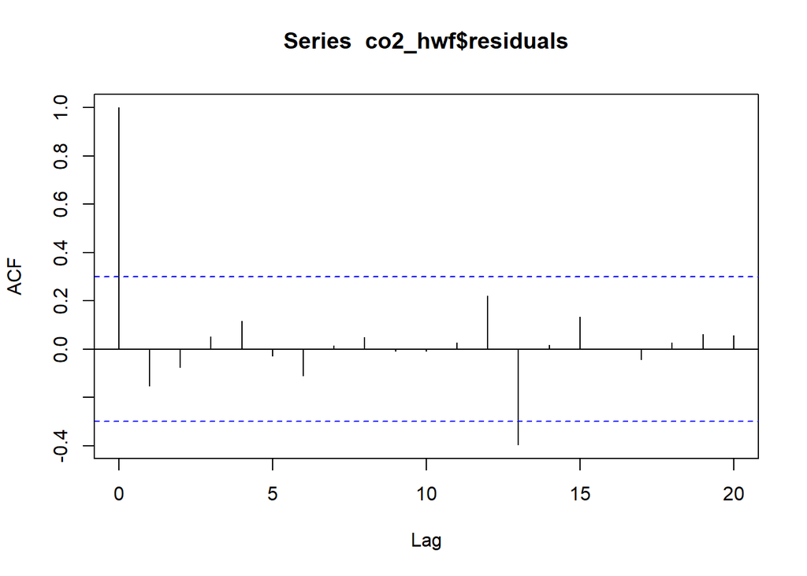

```r
# use na.action to tell the function that we should just omit the one NA value in our hwf
acf(co2_hwf$residuals, lag.max=20, na.action=na.pass)
```

`acf` is a built-in function that compute and (by default plots) the autocorrelation (default) or covariance of our univariate time series. We specified 20 to be the maximum lag at which to calculate the acf. If this is the first time you’ve across the word “lag” and autocorrelation, allow me to explain in greater details what they mean.

You’ve learned that we use correlation or covariance to compare two series of values and see how similar two time series are in their variation. Autocorrelation aims to describe the how similar the values of a time series is with other values within it.

Lag can be understood as the delay, or the gap, between values. For lag 0, the autocorrelation is comparing the entire time series with itself (and hence it is 1 in the ACF plot). For lag 1, the computation works by shifting the time series by 1 before comparing that time series with the shifted-by-1 series and it continues doing so for the whole length of the time series.

For a a timeseries that is “white noise”, where it comprises of completely random values throughout the length of its series, we expect to see no correlation anywhere else apart from at lag 0. It is a useful technique that reveals at what “lag” in the time series can we expect correlation.

Imagine stock prices of a public company over the last many years, sampled daily. You will find that the time series will exhibit a relatively high correlation in lag=1 (because the values of one day to a great extent correlates with the price tomorrow), but decrease quickly at lag=2. Supposed the company file its annual returns every 12 months and we use a monthly time unit, then we should expect some correlation at lag=12 as well.

Going back to the ACF plot above, by default it plots the 95% confidence interval as dotted blue lines: Observe that all sample autocorrelations except the one at 13 fall well inside the 95% confidence bounds indicating the residuals appear to be random. By pure random chance (because of the 95% CI), you’d expect to see one lag exceeding the 95% threshold for every 20 values.

### 2.4.4 Understanding ACF and PACF

Unlike regular sampling data, time-series are ordered which means there may exist additional information (any temporal patterns) in our data that we can take advantage of. The autocorrelation function gives us the correlation between point separated by various time lags. The notation is ACF(n) where *n* is the number of time periods between points, such that ACF(n) gives us the correlation between points separated by *n* time periods.

```r
acf(co2_hwf$residuals, lag.max=5, na.action=na.pass, plot=F)
```

```
##
## Autocorrelations of series 'co2_hwf$residuals', by lag
##
##      0      1      2      3      4      5
##  1.000 -0.152 -0.075  0.051  0.117 -0.028
```

So we’ve learned earlier that the ACF tells you how correlated the points are with each other in a given time series, based on how many time steps they are separated by. Typically, we would expect the autocorrelation function to fall towards 0 as points become more separated because it is as a rule of thumb harder to forecast further into the future from a given point of time.

The ACF and its close relative, the *partial* autocorrelation function (PACF) are used in the Box-Jenkins/ARIMA modeling approach to determine how past and future data points are related in a time series. The PACF can be thought of as the correlation between two points *but* with the effect of the intervening correlations removed. This is important because in reality, if each data point is only directly correlated with the *next* data point and none other, that correlation may “dribble down” leading us to believe that there is a correlation between the current point and a point down the future. For example, T1 is directly correlated with T2, which is directly correlated with T3. This causes T1 to look like it is directly correlated with T3 - so the PACF is a measure we use so any intervening correlation with T2 is eliminated leading us to better discern true patterns of correlations.

In general, the “partial” correlation between two variables is the amount of correlation between them that is not explained by their mutual correlations with a specified set of other variables. For example, if we are regressing variable “Y” on variables X1, X2 and X3, the partial correlation of X3 and Y can be computed as the square root of the reduction in variance that is achieved by adding X3 to the regression of Y on X1 and X2.

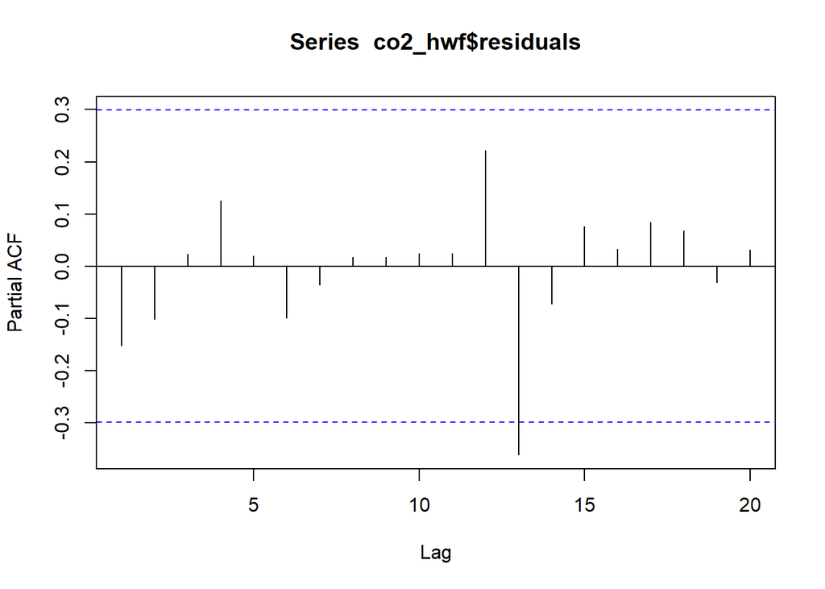

```r
pacf(co2_hwf$residuals, lag.max=20, na.action=na.pass)
```

### 2.4.5 Ljung-box Test

Now going back to the earlier correlogram we plotted: notice that the autocorrelation at lag 13 is just touching the significance bounds - to test whether there is significant evidence for non-zero correlations at lag 1-20, we can perform a Ljung-Box test using the `Box.test()` function. The maximum lag that we want to look at is specified using the `lag` parameter. We will use the Ljung-Box test to determine whether our residuals are random:

```r
Box.test(co2_hwf$residuals, lag=20, type="Ljung-Box")
```

```
##
##  Box-Ljung test
##
## data:  co2_hwf$residuals
## X-squared = 17.942, df = 20, p-value = 0.5912
```

Here the Ljung-Box test statistic is 17.94, and the p-value is 0.6, so there is little evidence of non-zero autocorrelations in the in-sample forecast errors at lag 1-20. The Ljung-Box test statistic (X-squared) gets larger as the sample auto-correlations of the residuals get larger - without going too far beyond of this scope of the coursebook, here’s the general idea:

For a *p-value < 0.05*: You can reject the null hypothesis (no auto-correlation) and know that you have less than 5% chance of making an error. This also mean we can assume that our values are showing dependence on each other. So really we want to see large values.

For a *p-value > 0.05*: Don’t have enough evidence to reject the null hypothesis (no correlation), so we assume our values are random (no structure in the data) - or that there is no dependence on each other.

Lastly, to be sure that the predictive model cannot be furthed improved upon, let’s check that the errors are approximately normally distributed with mean zero and constant variance:

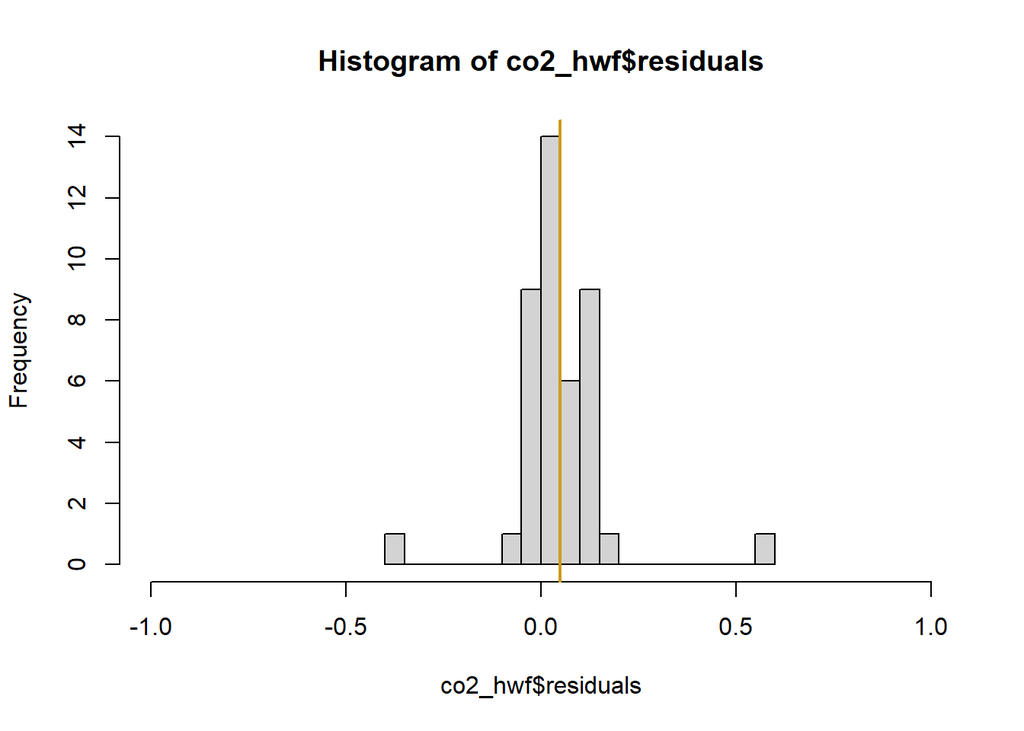

```r
hist(co2_hwf$residuals, breaks=20, xlim=c(-1,1))
abline(v=mean(co2_hwf$residuals, na.rm=T), col="goldenrod3", lwd=2)
```

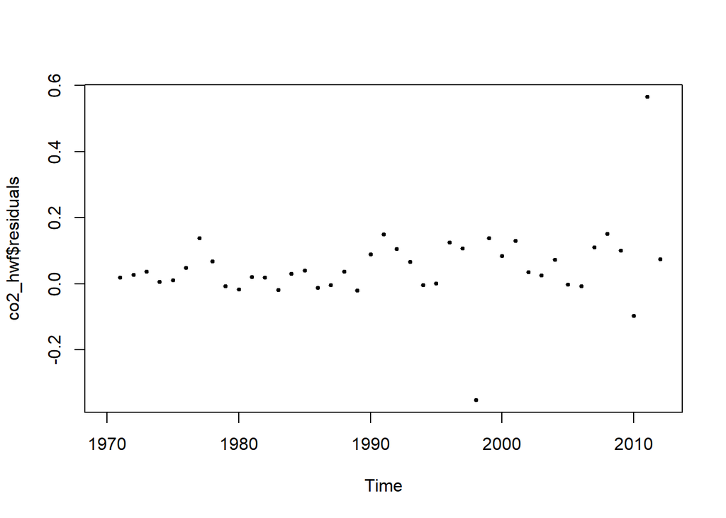

```r
plot(co2_hwf$residuals, type="p", pch=19, cex=0.5)
```

Before we conclude, recall again from our Ljung-Box test that there is little evidence of non-zero correlations in the in-sample forecast errors, and the distribution of our errors do also seem to approximate normal with mean ~0: both of which suggests that the simple exponential smoothing do provide an adequate predictive model for the Indonesia’s CO2 emission forecast. We’d reason that the assumptions that the 95% prediction intervals were based upon are valid given: - No autocorrelations in the forecast errors  
- Forecast error (residuals) are normally distributed

## 2.5 Holt’s Exponential Smoothing

If we have a time series that can be described using an additive model with a trend component but no seasonality, we can use Holt’s exponential smoothing to make short-term forecasts.

Holt’s exponential smoothing (known also as Double Exponential Smoothing) estimates the level and slope at the current time point. Smoothing is controlled by:  
- $\alpha$: the estimate of the level at the current time point  
- $\beta$: the estimate of the slope *b* of the trend component at the current time point *t*

Both alpha and beta take a value between 0 and 1 and values closer to 0 puts less weight on recent observations - just as it works in simple exponential smoothing. By introducing a second equation (beta) Holt’s exponential smoothing uses the formulas:  
- $s_1 = x_1$  
- $b_1 = x_1 - x_0$

And for t > 2, it is represented by:  
- $s_t = \alpha x_t + (1-a)(s_{t-1} + b_{t-1})$  
- $b_t = \beta(s_t - s_{t-1}) + (1-\beta)b_{t-1}$

Recalling that $\alpha$ is our overall smoothing factor and $\beta$ is our trend smoothing factor.

To forecast beyond $x_t$:  
$F_{t+m} = s_t + mb_t$

Some suggestions to initialize $b_0$ is to use:  
- $b_1 = x_1 - x_0$ - $b_1 = \frac{1}{3}[(x_1-x_0) + (x_2-x_1) + (x_3-x_2)]$ - $b_1 = \frac{x_n - x_1}{n-1}$

Notice that in the first smoothing equation, we adjust $s_t$ directly for the trend of the previous period (hence adding $s_{t-1} + b_{t-1}$). This helps to eliminate the lag and brings $s_t$ to the appropriate base of the current value.

The second smoothing equation then updates the trend, which is expressed as the difference between the last two values ($s_t - s_{t-1}$). The equation is similar to the basic form of single smoothing, but here applied to the updating of the trend.

If you have followed along the earlier exercise, you’ve re-written the following code (removing `beta=FALSE` from the function call):

```r
co2_holt <- HoltWinters(co2_ts, gamma=F)
co2_holt
```

```
## Holt-Winters exponential smoothing with trend and without seasonal component.
##
## Call:
## HoltWinters(x = co2_ts, gamma = F)
##
## Smoothing parameters:
##  alpha: 0.7468631
##  beta : 0.1106535
##  gamma: FALSE
##
## Coefficients:
##         [,1]
## a 2.38054022
## b 0.09548633
```

```r
# confirmation that the Holt's model is an improvement over co2_hw
```

Notice that the Holt’s Exponential Smoothing model estimates the parameters for the trend component (beta) in our time series in addition to `alpha`, which we’re familiar with.

The estimated value of alpha is 0.75 and of beta is 0.11. Alpha is high - indicating that the estimate of the overall smoothing are based more strongly on very recent observations in the time series; The trend smoothing (slope) is estimated from observations that are recent as well as more distant and that makes pretty good intuitive sense if we visually inspect the time series again:

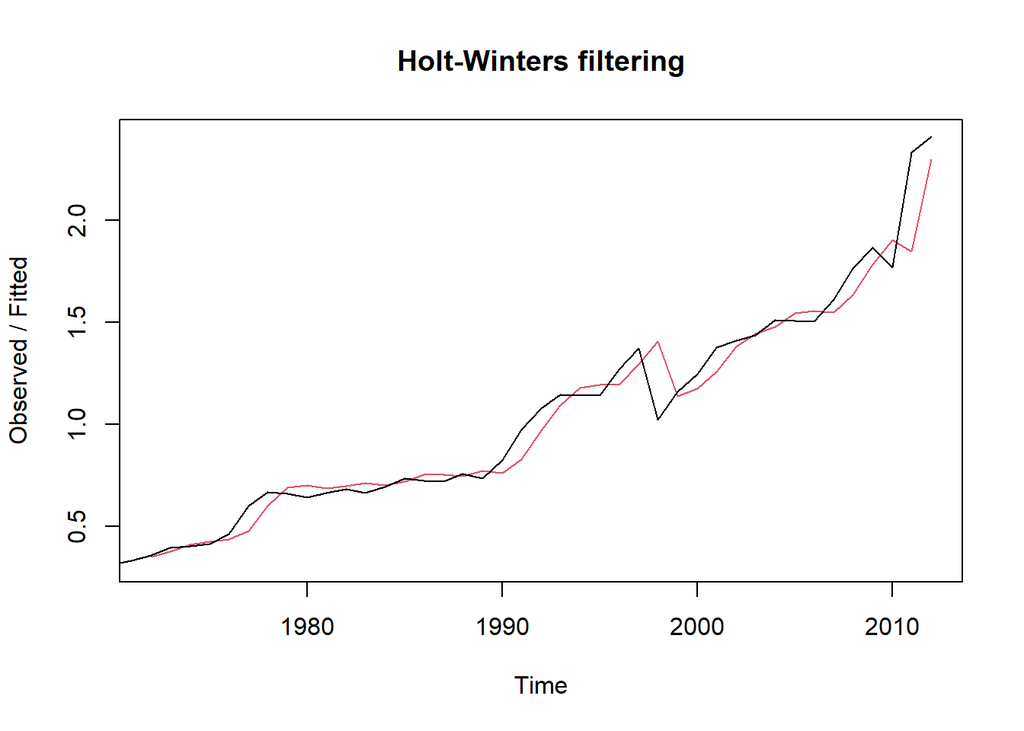

```r
plot(co2_holt)
```

Observe that the in-sample forecasts agree pretty well with the observed values, although they tend to lag behind the observed values a bit. If we want, we can specify the initial values of the level and slope b of the trend component using the `l.start` and `b.start` arguments. It is common to set the initial value of the level to the first value in the time series (recall $s_1 = x_1$) and the initial value of the slope to the second value minus the first value (recall $b_1 = x_1 - x_0$), so fitting a predictive model with initial values would look like this:

```r
co2_holt2 <- HoltWinters(co2_ts, gamma=F, l.start=co2_ts[1], b.start=co2_ts[2]-co2_ts[1])
head(co2_holt2$x)
```

```
## Time Series:
## Start = 1970
## End = 1975
## Frequency = 1
## [1] 0.3119519 0.3306215 0.3580080 0.3954703 0.4021567 0.4128050
```

We can also make forecasts for future times not covered by the original time series using the `forecast.HoltWinters()` function. Let’s make predictions for 2013 to 2020 (8 more data points), and plot them:

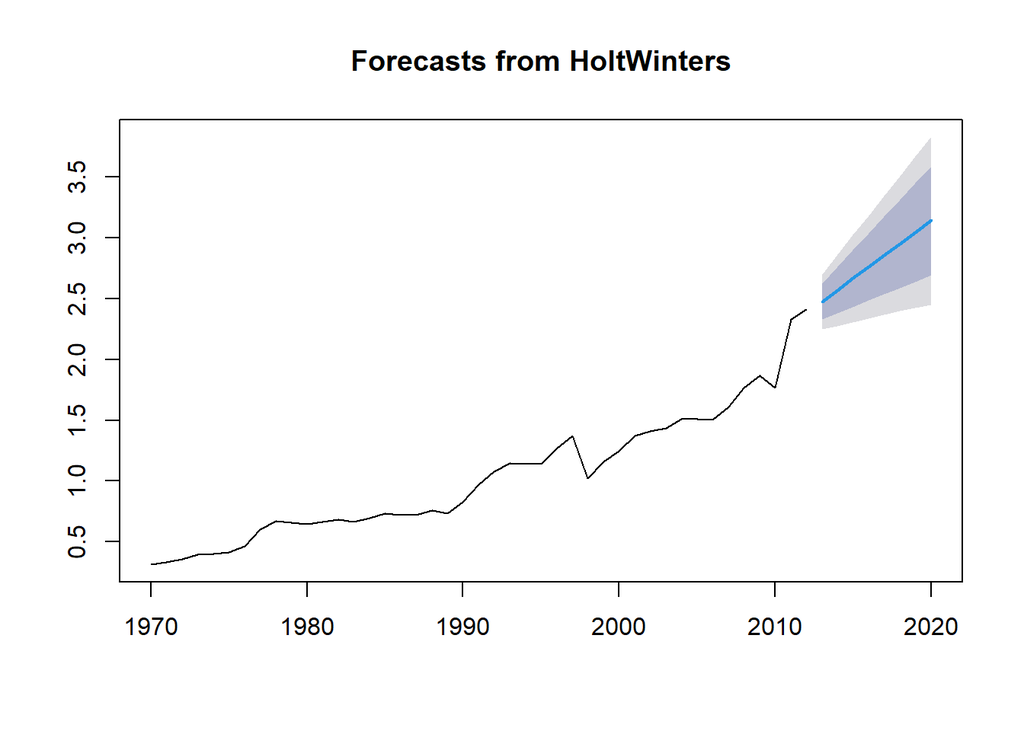

```r
co2_hwf2 <- forecast(co2_holt2, h=8)
plot(co2_hwf2)
```

The plot gives us a forecast (blue line), a 80% prediction interval and a 95% prediction interval. Let’s apply what we’ve learned earlier to see if the model could be improved upon by identifying whether the in-sample forecast errors show any non-zero autocorrelations at lags 1-20 using a correlogram plot:

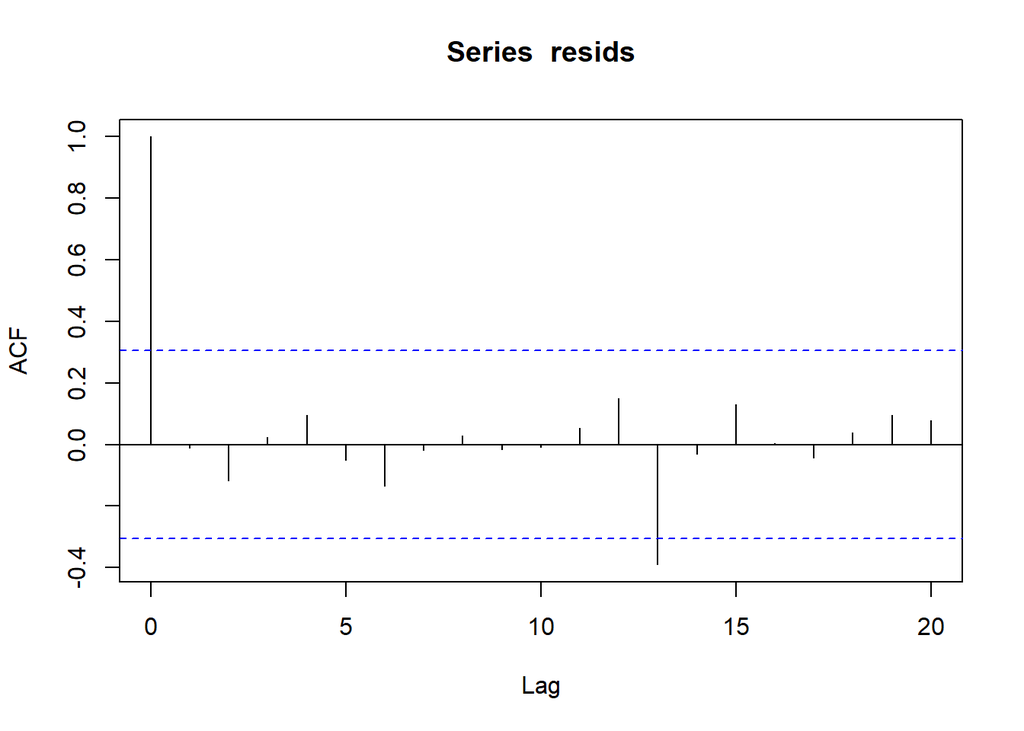

```r
# remove the first two residuals values as they are NA (no residuals)
resids <- co2_hwf2$residuals[3:43]
acf(resids, lag.max=20)
```

Observe from the above correlogram that the in-sample forecast errors at lag 13 exceeds the significance bounds. Again, we would expect one in 20 of the autocorrelations to exceed the 95% significance bounds by chance alone.

```r
Box.test(resids, lag=20, type="Ljung-Box")
```

```
##
##  Box-Ljung test
##
## data:  resids
## X-squared = 15.973, df = 20, p-value = 0.7183
```

Indeed, with the Ljung-Box test we obtain a p-value of 0.72, indicating that there is little evidence of a non-zero autocorrelations in the in-sample forecast errors at lag 1-20.

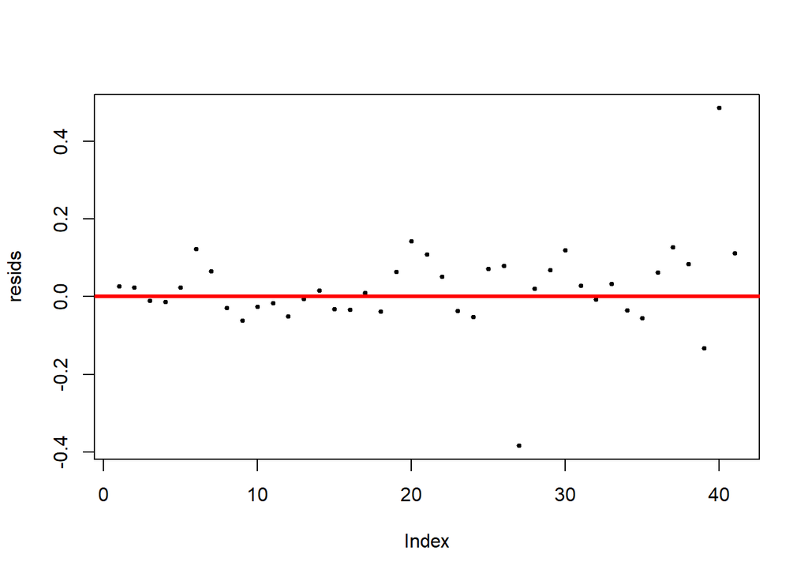

```r
plot(resids, cex=0.5, pch=19)
abline(h=0, col="red", lwd=3)
```

Observe that the errors do seem to have roughly constant variance over time and that that our errors are normally distributed with mean zero and almost constant variance.

## 2.6 Holt-Winters Exponential Smoothing

If we have a time series that can be described using an additive model with increasing or decreasing trend and seasonality, we can use Holt-Winters exponential smoothing to make short-term forecasts.

Holt-Winters exponential smoothing **estimates the level, slope and seasonal component** at the current time point, and is controlled by $\alpha$, $\beta$ and $\gamma$ for the estimates of the level, slope b of the trend component, and the seasonal component respectively. They all take values between 0 and 1, with 0 giving little weight to the most recent observations when making forecasts of future values. Let’s read the time series of the log of monthly sales for the souvenir shop at a beach resort town in Queensland:

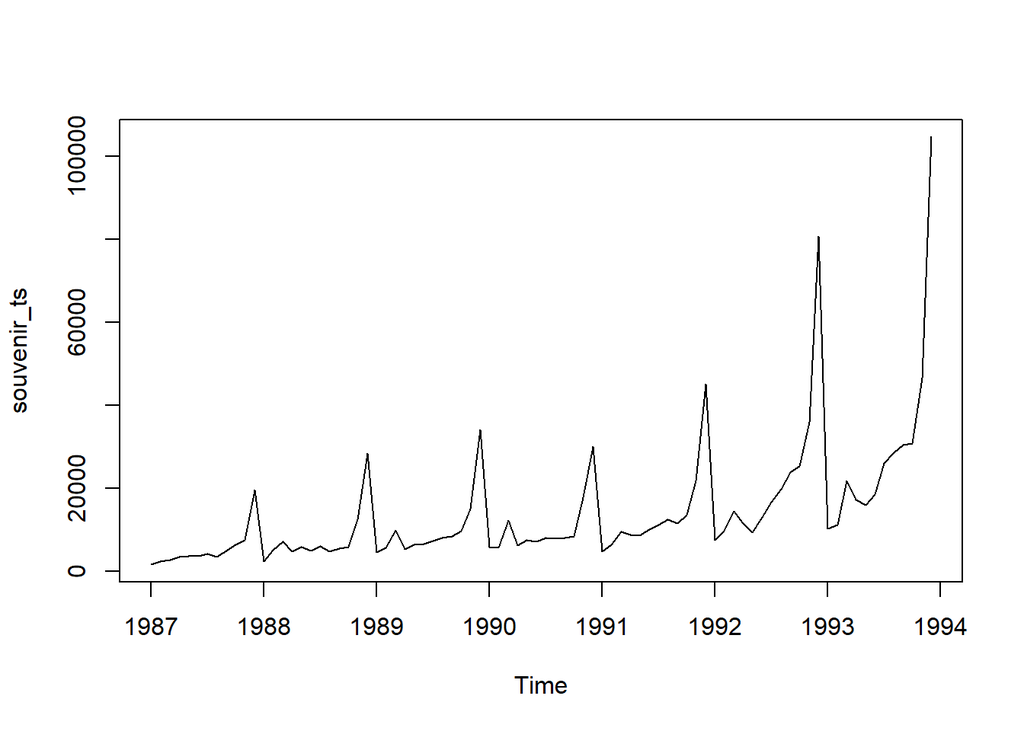

```r
souvenir <- scan("data_input/fancy.dat", quiet = T)
souvenir_ts <- ts(souvenir, frequency = 12, start = c(1987,1))
plot(souvenir_ts)
```

It looks like it’s a multiplicative time series - we’ll apply a log-transformation on the series and apply Holt Winters on the resulting series:

```r
souv_hw <- HoltWinters(log(souvenir_ts))
souv_hw
```

```
## Holt-Winters exponential smoothing with trend and additive seasonal component.
##
## Call:
## HoltWinters(x = log(souvenir_ts))
##
## Smoothing parameters:
##  alpha: 0.413418
##  beta : 0
##  gamma: 0.9561275
##
## Coefficients:
##            [,1]
## a   10.37661961
## b    0.02996319
## s1  -0.80952063
## s2  -0.60576477
## s3   0.01103238
## s4  -0.24160551
## s5  -0.35933517
## s6  -0.18076683
## s7   0.07788605
## s8   0.10147055
## s9   0.09649353
## s10  0.05197826
## s11  0.41793637
## s12  1.18088423
```

The estimated values of alpha (0.41) is relatively low, indicating that the estimate of the level at the current time point is based upon both recent observations and some observations in the more distant past.

The value of beta is 0.00 indicating that the estimate of the slope b of the trend component is not updated over the time series and instead is set equal to its initial value. This makes good intuitive sense as the level changes quite a bit over time but the slope b of the trend component remains roughly the same:

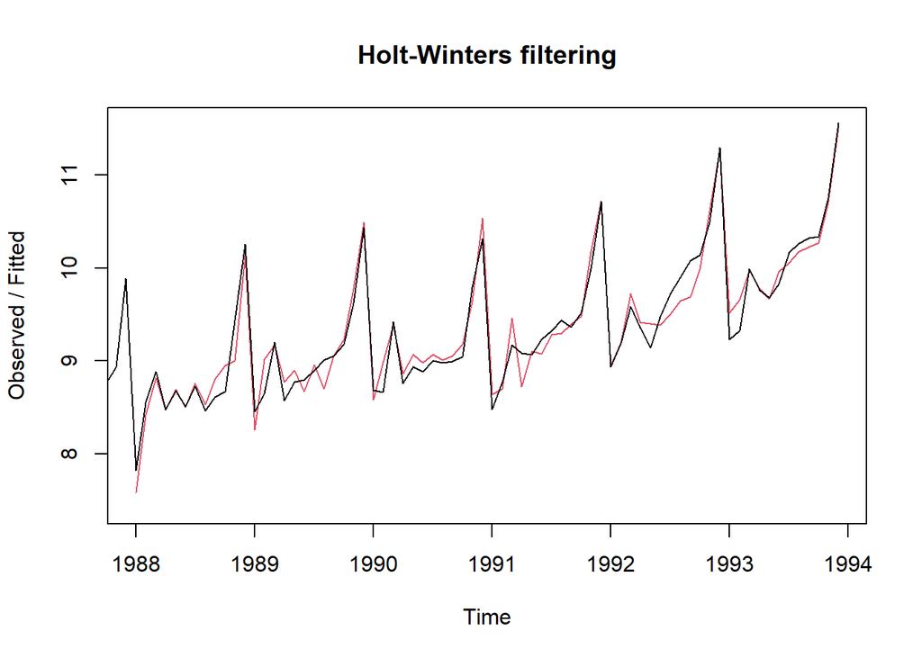

```r
plot(souv_hw)
```

In contrast, the value of gamma (0.96) is high, indicating that the estimate of the seasonal component at the current time point is just based upon very recent observations.

### 2.6.1 Understanding Holt-Winters

Holt-Winters method, also known as the triple exponential smoothing was first suggested by Holt’s student Peter Winters and introduces a third equation in addition to the two in Holt’s method to account for seasonality. Generally, to produce forecasts (assuming additive seasonality), the formula would be:  
Forecast = Most recent estimated level + trend + seasonality

And for multiplicative seasonality, we would instead use:  
Forecast = Most recent estimated (level + trend) * seasonality

The equations for multiplicative seasonality are: - Overall smoothing: $s_t = \alpha\frac{x_t}{I_{t-L}}+(1-\alpha)(s_{t-1} + b_{t-1})$  
- Trend smoothing: $b_t = \beta(s_t - s_{t-1})+(1-\beta)b_{t-1}$  
- Seasonal smoothing: $I_t = \gamma\frac{x_t}{s_t} + (1-\gamma)I_{t-L}$  
-Forecast: $F_{t+m} = (s_t + mb_t)I_{t-L+m}$

Where alpha, beta and gamma are estimated in a way that minimizes the MSE of the error, and: - $x$ is the observation  
- $s$ is the smoothed observation  
- $b$ is the trend factor  
- $I$ is the seasonal index (sequence)  
- $F$ is the forecast at *m* periods ahead  
- $t$ is an index denoting a time period  
- $L$ is the number of periods in a season

Notice the $I_{t-L}$ in our formula: this makes sense because $I_t$ is the sequence of seasonal correction factors so a t value of 6 in a 4-period season (Q1 to Q4) would refer to the seasonal correction factor of the second period(Q2).

A complete season’s data consists of *L* periods, and we need to estimate the trend factor from one period to the next. To accomplish this, it is advisable to have at least two complete seasons.

The general formula to estimate the initial trend *b*:  
$b = \frac{1}{L}(\frac{x_{L+1}-x_1}{L}+\frac{x_{L+2}-x_2}{L} ... + \frac{x_{L+L}-x_L}{L})$

Now onto finding the initial values for the seasonal indices. To make things less abstract, assume we’re working with data that consist of 5 years and 4 periods (4 Quarters per year):

- Step 1: Compute the averages of each of the 5 years ($A_1...A_5$)
- Step 2: Divide the observations by the appropriate yearly mean

```r
library(htmlTable)
A <- rbind.data.frame(
  c("y<sub>1</sub>/A<sub>1</sub>","y<sub>5</sub>/A<sub>2</sub>","y<sub>9</sub>/A<sub>3</sub>","y<sub>13</sub>/A<sub>4</sub>","y<sub>17</sub>/A<sub>5</sub>"),
  c("y<sub>2</sub>/A<sub>1</sub>","y<sub>6</sub>/A<sub>2</sub>","y<sub>10</sub>/A<sub>3</sub>","y<sub>14</sub>/A<sub>4</sub>","y<sub>18</sub>/A<sub>5</sub>"),
  c("y<sub>3</sub>/A<sub>1</sub>","y<sub>7</sub>/A<sub>2</sub>","y<sub>11</sub>/A<sub>3</sub>","y<sub>15</sub>/A<sub>4</sub>","y<sub>19</sub>/A<sub>5</sub>"),
  c("y<sub>4</sub>/A<sub>1</sub>","y<sub>8</sub>/A<sub>2</sub>","y<sub>12</sub>/A<sub>3</sub>","y<sub>16</sub>/A<sub>4</sub>","y<sub>20</sub>/A<sub>5</sub>")
)

htmlTable(A, css.cell="padding:0 2em;font-size:0.8em", align="c", header=c("Year 1","Year 2","Year 3","Year 4","Year 5"))
```

|  | Year 1 | Year 2 | Year 3 | Year 4 | Year 5 |
| --- | --- | --- | --- | --- | --- |
| 1 | y<sub>1</sub>/A<sub>1</sub> | y<sub>5</sub>/A<sub>2</sub> | y<sub>9</sub>/A<sub>3</sub> | y<sub>13</sub>/A<sub>4</sub> | y<sub>17</sub>/A<sub>5</sub> |
| 2 | y<sub>2</sub>/A<sub>1</sub> | y<sub>6</sub>/A<sub>2</sub> | y<sub>10</sub>/A<sub>3</sub> | y<sub>14</sub>/A<sub>4</sub> | y<sub>18</sub>/A<sub>5</sub> |
| 3 | y<sub>3</sub>/A<sub>1</sub> | y<sub>7</sub>/A<sub>2</sub> | y<sub>11</sub>/A<sub>3</sub> | y<sub>15</sub>/A<sub>4</sub> | y<sub>19</sub>/A<sub>5</sub> |
| 4 | y<sub>4</sub>/A<sub>1</sub> | y<sub>8</sub>/A<sub>2</sub> | y<sub>12</sub>/A<sub>3</sub> | y<sub>16</sub>/A<sub>4</sub> | y<sub>20</sub>/A<sub>5</sub> |

- Step 3: Now the seasonal indices are formed by computing the average of each row. Thus the seasonal indices are computed:  
  $I_1 = (y_1/A_1 + y_5/A_2 + y_9/A_3 + y_{13}/A_4 + y_{17}/A_5)/5$  
  (substitute $I_1$ for $I_t$)